# Final Project Check-Up Memo

Data Science 1 with R (STAT 301-1)

Author

Ryan Nguyen

## Load Packages

```r
library(tidyverse, quietly = T)
library(skimr, quietly = T)
library(lubridate, quietly = T)
library(maps)
```

## Demonstartion of Progress

```r
charts <- read_csv("data/charts.csv", show_col_types = FALSE)
grammy_albums <- read_csv("data/grammy_albums.csv", show_col_types = FALSE)
grammy_songs <- read_csv("data/grammy_songs.csv", show_col_types = FALSE)
billboard100 <- read_csv("data/billboard100.csv", show_col_types = FALSE)
artists <- read_csv("data/artistDF.csv", show_col_types = FALSE)
```

```r
taylor_charts <- charts %>%
  filter(str_detect(artists, pattern = "Taylor Swift")) %>%
  mutate(name = str_replace(name, "Taylor's Version", "TV"),
         name = str_replace(name, "From The Vault", "FTV")) %>%
  select(name, artists, country, date, position, streams)

taylor_charts
```

```
# A tibble: 16,708 × 6
   name                       artists         country date       posit…¹ streams
   <chr>                      <chr>           <chr>   <date>       <dbl>   <dbl>
 1 It’s Nice To Have A Friend ['Taylor Swift… global  2019-08-23      44 1801520
 2 It’s Nice To Have A Friend ['Taylor Swift… global  2019-08-24      63 1234566
 3 It’s Nice To Have A Friend ['Taylor Swift… global  2019-08-25      72  979257
 4 It’s Nice To Have A Friend ['Taylor Swift… global  2019-08-26      67 1083248
 5 It’s Nice To Have A Friend ['Taylor Swift… global  2019-08-27      97  939042
 6 It’s Nice To Have A Friend ['Taylor Swift… global  2019-08-28     117  863392
 7 It’s Nice To Have A Friend ['Taylor Swift… global  2019-08-29     152  779063
 8 It’s Nice To Have A Friend ['Taylor Swift… us      2019-08-23      23 1016790
 9 It’s Nice To Have A Friend ['Taylor Swift… us      2019-08-24      34  659588
10 It’s Nice To Have A Friend ['Taylor Swift… us      2019-08-25      41  502489
# … with 16,698 more rows, and abbreviated variable name ¹position
```

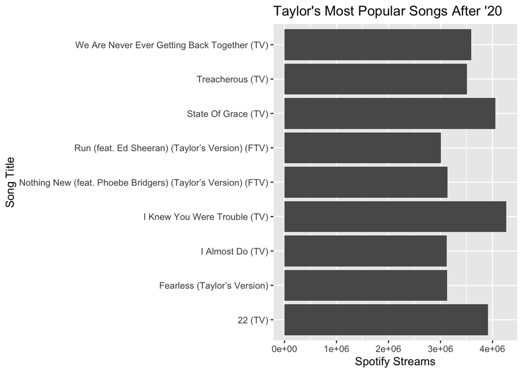

```r
taylor_charts %>%
  filter(streams > 3000000, year(date) > 2020) %>%
  ggplot(aes(x = name, y = streams)) +
  geom_col() +
  coord_flip() +
  labs(title = "Taylor's Most Popular Songs After '20", x = "Song Title", y = "Spotify Streams")
```

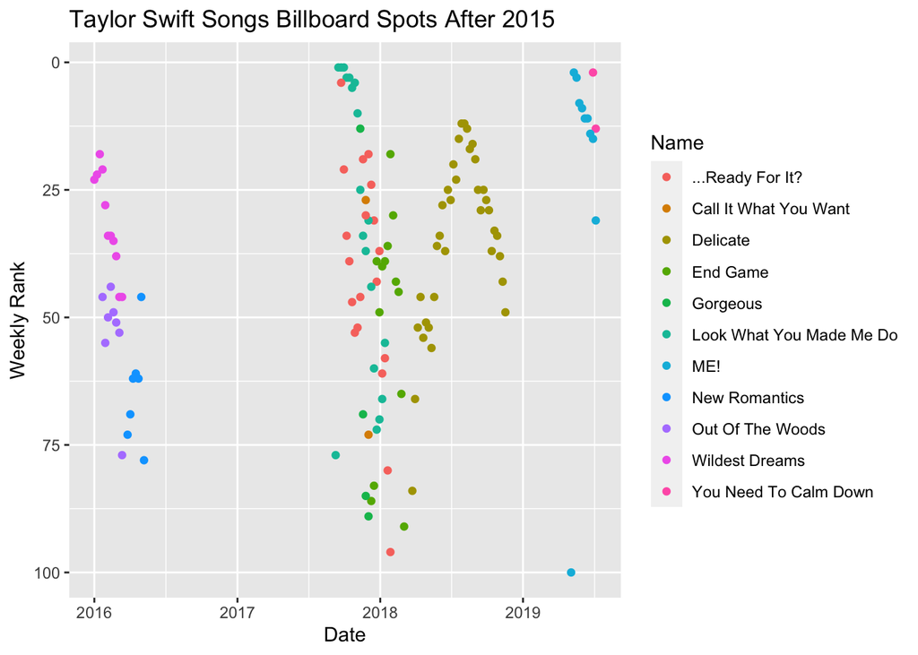

```r
billboard100 %>%
  filter(Artists == "Taylor Swift", year(Week) > 2015) %>%
  ggplot(aes(x = Week, y = Weekly.rank, color = Name)) +
  geom_point() +
  scale_y_reverse() +
  labs(title = "Taylor Swift Songs Billboard Spots After 2015",
       x = "Date",
       y = "Weekly Rank")
```

```r
# trying to join datasets, but issues with the artists strings not exactly matching
charts2<- charts %>%
  mutate(artists <- str_replace(artists, "\\[\\'.*\\'\\]", "r"))

charts2
```

```
# A tibble: 626,475 × 11
   track_id     name  country date       posit…¹ streams artists artis…² durat…³
   <chr>        <chr> <chr>   <date>       <dbl>   <dbl> <chr>   <chr>     <dbl>
 1 7GMeRGZax4u… It W… br      2015-03-17     138    6584 ['Maro… ['pop']  239920
 2 7GMeRGZax4u… It W… br      2015-03-18     132    6963 ['Maro… ['pop']  239920
 3 7GMeRGZax4u… It W… br      2015-03-19     128    7049 ['Maro… ['pop']  239920
 4 7GMeRGZax4u… It W… br      2015-03-20     152    6976 ['Maro… ['pop']  239920
 5 7GMeRGZax4u… It W… br      2015-03-21     160    6156 ['Maro… ['pop']  239920
 6 7GMeRGZax4u… It W… br      2015-03-23     120    6969 ['Maro… ['pop']  239920
 7 7GMeRGZax4u… It W… br      2015-06-01     172    7461 ['Maro… ['pop']  239920
 8 7GMeRGZax4u… It W… br      2015-06-03     200    7197 ['Maro… ['pop']  239920
 9 7GMeRGZax4u… It W… it      2015-03-17     136    4672 ['Maro… ['pop']  239920
10 7GMeRGZax4u… It W… it      2015-03-18     155    4002 ['Maro… ['pop']  239920
# … with 626,465 more rows, 2 more variables: explicit <lgl>,
#   `artists <- str_replace(artists, "\\\\[\\\\'.*\\\\'\\\\]", "r")` <chr>, and
#   abbreviated variable names ¹position, ²artist_genres, ³duration
```

## Assessment of Progress

After many hours, I am mostly satisfied with my progress. I am really excited about the various data sets that I’ve pulled and am satisfied with the analysis and plots that I have created so far. I think the data sets allow for a lot of different explorations, and I think my next step is to make a list of all of the analysis I want to specifically explore. I’m interested in learning more about the correlation between the billboard charts, awards, and spotify charts, and how the different platforms may or may not affect one another for specific artists or songs. A roadblock/issue I am running into is the fact that the artists in the `charts` data set is listed as “[‘Artist Name’]” whereas they are listed as “Artist Name” in the `billboard100` data set. So, when I attempt to merge the two data sets, they don’t merge since the strings are slightly different. I am continually trying to fix this by using `str_replace` to edit the artists’ names in `charts`, or seeing if there is code to partially match the names. As I work more and more with the data, I am fascinated by how many observations overtime has been collected, and I am excited to explore what more I can do with it.

## Demonstration of Organization

Below is a screenshot of my folder with the RStudio project.

[figure not shown]